# Applied Data Science Final Project

Andy Doto

4/27/2019

# Final Project

## Stating the question

As society grows and evolves, it is important to understand the outcomes of nations around the world. As technology advances and improves lives, understanding the impact can be vital in moving forward. The gapminder dataset, which will be used in this project, provides historical data for nations over the world. According to Peng and Matsui (2016) in the *The Art of Data Science: A guide for anyone who works with Data*, an exploratory question type describes how I will approach this final project, as I analyze the data to explore trends and relationships within the dataset. One interesting question to explore is if the income per person of a nation impacts the lifespan of the population.

## Describing the data

For this final project, I will be exploring the gapminder dataset, which was provided by the instructors.

**Attribute Information:**

- Country
- Year
- Lifespan
- Population
- Income per person (GDP)
- Region

```
## The number of observations is 41284
```

```
## The number of variables is 6
```

```
##     Country        Year        life  population      income      region
## "character"   "numeric"   "numeric"   "numeric"   "numeric" "character"
```

Below is a summary of the data. As you will notice, for each column, descriptive stats are provided.

```
##    Country               Year           life         population
##  Length:41284       Min.   :1800   Min.   : 1.00   Min.   :1.548e+03
##  Class :character   1st Qu.:1854   1st Qu.:31.00   1st Qu.:5.335e+05
##  Mode  :character   Median :1908   Median :35.12   Median :3.358e+06
##                     Mean   :1907   Mean   :42.88   Mean   :2.119e+07
##                     3rd Qu.:1962   3rd Qu.:55.60   3rd Qu.:1.078e+07
##                     Max.   :2015   Max.   :84.10   Max.   :1.376e+09
##                                                    NA's   :25817
##      income          region
##  Min.   :   142   Length:41284
##  1st Qu.:   883   Class :character
##  Median :  1450   Mode  :character
##  Mean   :  4571
##  3rd Qu.:  3483
##  Max.   :182668
##  NA's   :2341
```

As you will notice, the population column has many missing values. This is due to the fact that the population was recorded only every ten years. To handle this, we will use the fill verb from the dplyr package to fill the values forward. Here is the summary with the population values filled:

```
##    Country               Year           life         population
##  Length:41284       Min.   :1800   Min.   : 1.00   Min.   :1.548e+03
##  Class :character   1st Qu.:1854   1st Qu.:31.00   1st Qu.:2.530e+05
##  Mode  :character   Median :1908   Median :35.12   Median :1.584e+06
##                     Mean   :1907   Mean   :42.88   Mean   :1.260e+07
##                     3rd Qu.:1962   3rd Qu.:55.60   3rd Qu.:5.583e+06
##                     Max.   :2015   Max.   :84.10   Max.   :1.376e+09
##
##      income          region
##  Min.   :   142   Length:41284
##  1st Qu.:   883   Class :character
##  Median :  1450   Mode  :character
##  Mean   :  4571
##  3rd Qu.:  3483
##  Max.   :182668
##  NA's   :2341
```

## Exploring the data

### Exploratory Plots

For this next section, let’s go ahead and explore the data, using various tables and visualizations.

First, let’s take a look at the median income per person by continent

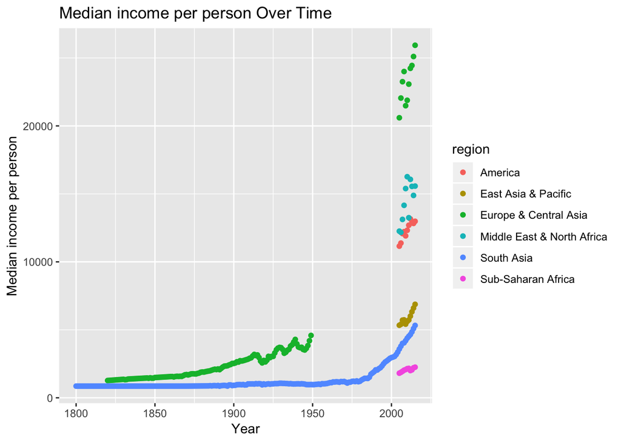

In this figure, you can see firstly, that there are some missing values. So we will need to handle that. Also, the general trend that we see is that over time, the median GDP of nations has grown, so that is potentially something to explore as well.

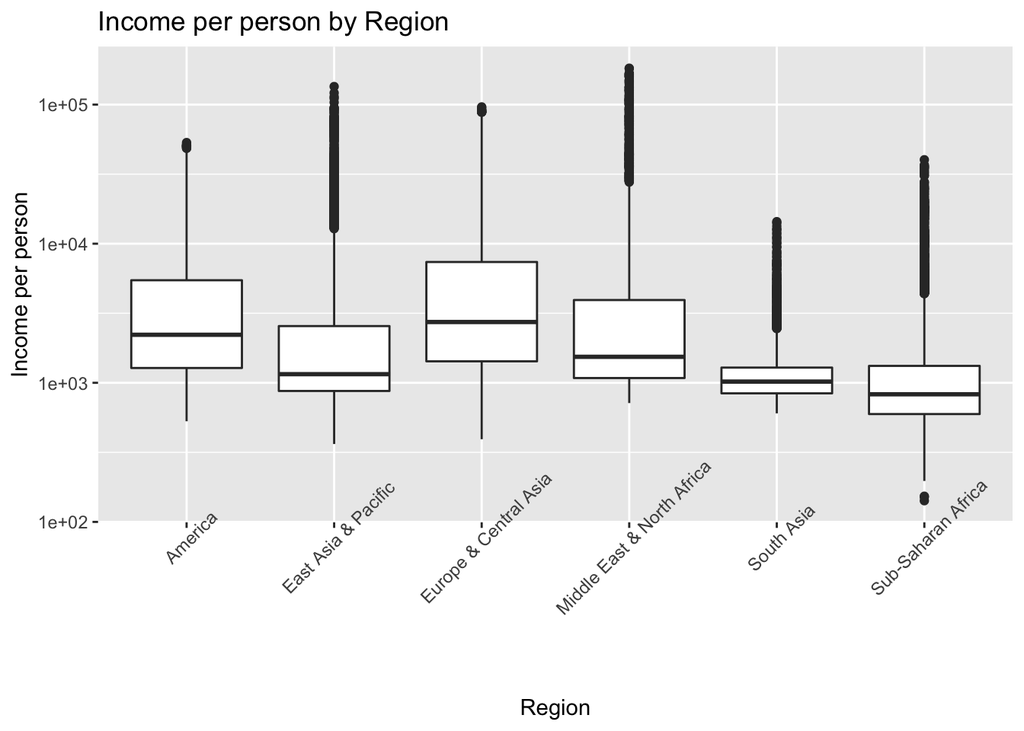

For this figure, the box plots compare the GDPs of regions. As you can see, the Americas and Europe have high medians, but it appears that there are nations in other regions that are outliers. That is worth exploring as well.

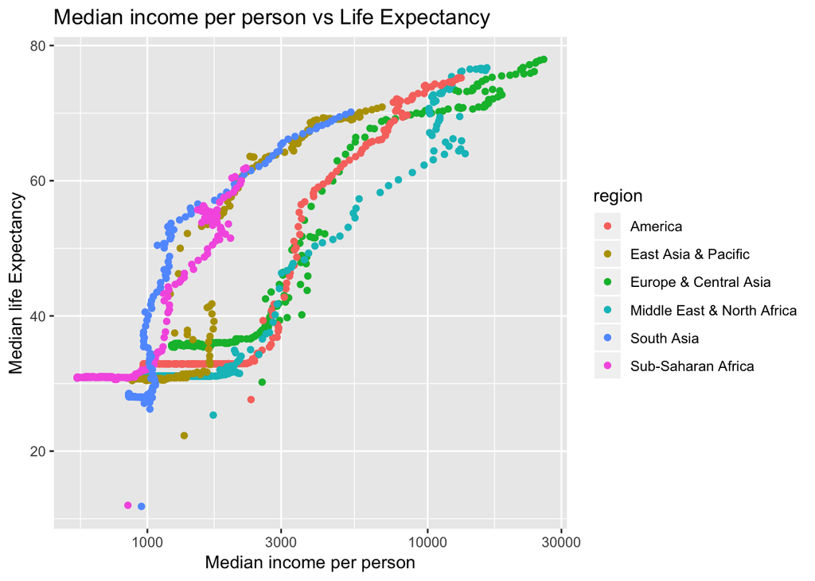

For this figure above, we have plotted the median income per person on the x axis and the median life expectancy on the y axis. This plot is interesting because it suggests some kind of potential relationship between these two variables. As income increases, as does the life expectancy. The figure also displays how this pattern generally holds true for each region as well. Using this observation, let’s try to explore this relationship further.

### Cluster analysis

For this next section, let’s try to run a cluster analysis on the data set. For this, we will utilize the summarized data set that calculated the median income per person and median life expectancy, grouped by year and region.

In order to find the ideal number clusters, let’s use the elbow method. With this, we will calculate the total within-cluster sum of squares for a various amount of clusters and plot it. At the point of the visualization where the decrease in the sum of squares becomes minimal, that number of clusters is ideal.

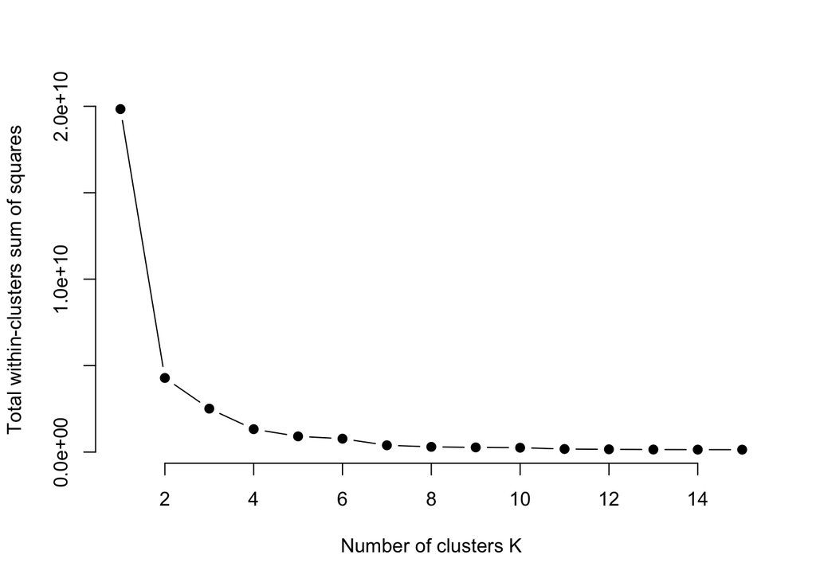

From analyzing the figure above, it appears that the “elbow” is at 4 clusters, so that is what we will choose for our number of clusters.

```
## List of 9
##  $ cluster     : int [1:1296] 4 4 4 4 4 4 4 4 4 4 ...
##  $ centers     : num [1:4, 1:2] 18120.8 4259.3 10750 1253.7 74.5 ...
##   ..- attr(*, "dimnames")=List of 2
##   .. ..$ : chr [1:4] "1" "2" "3" "4"
##   .. ..$ : chr [1:2] "median_income" "median_life"
##  $ totss       : num 1.98e+10
##  $ withinss    : num [1:4] 4.73e+08 2.88e+08 3.33e+08 2.30e+08
##  $ tot.withinss: num 1.32e+09
##  $ betweenss   : num 1.85e+10
##  $ size        : int [1:4] 41 183 98 974
##  $ iter        : int 4
##  $ ifault      : int 0
##  - attr(*, "class")= chr "kmeans"
```

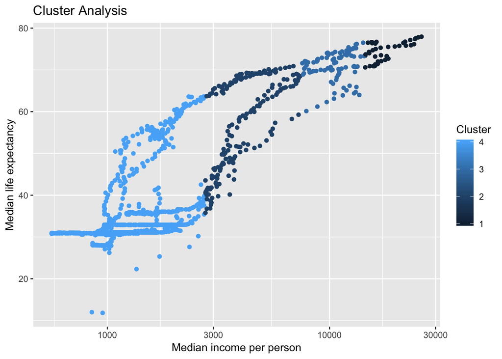

Upon analysis of the figure above, you can notice that the clusters do not relate to the regions of the countries. This suggests that further analysis is needed and that more variables need to be used to train the k means model. It would be interesting to run the k means model on more variables that can detect clusters of “alike” nations.

### Regression analysis

For this next section, let’s run a linear regression model on the data. With this model, you must select predictor variable(s) and a response variable. In this case, because of the pattern that we noticed in the exploration, let’s run a model with median life expectancy as the response variable and median life income per person as the predictor.

```
##
## Call:
## lm(formula = median_life ~ median_income, data = gdf)
##
## Coefficients:
##   (Intercept)  median_income
##     32.937461       0.003122
```

After running the regression model, we can see the summary from the output above. What this summary table tells us is that the coefficient for median income per person is 0.003122 and the intercept is 32.937461. This means that the regression formula is median life expectancy = 0.003122(median income per person) + 32.937461. Let’s visualize the best fit line created by the model

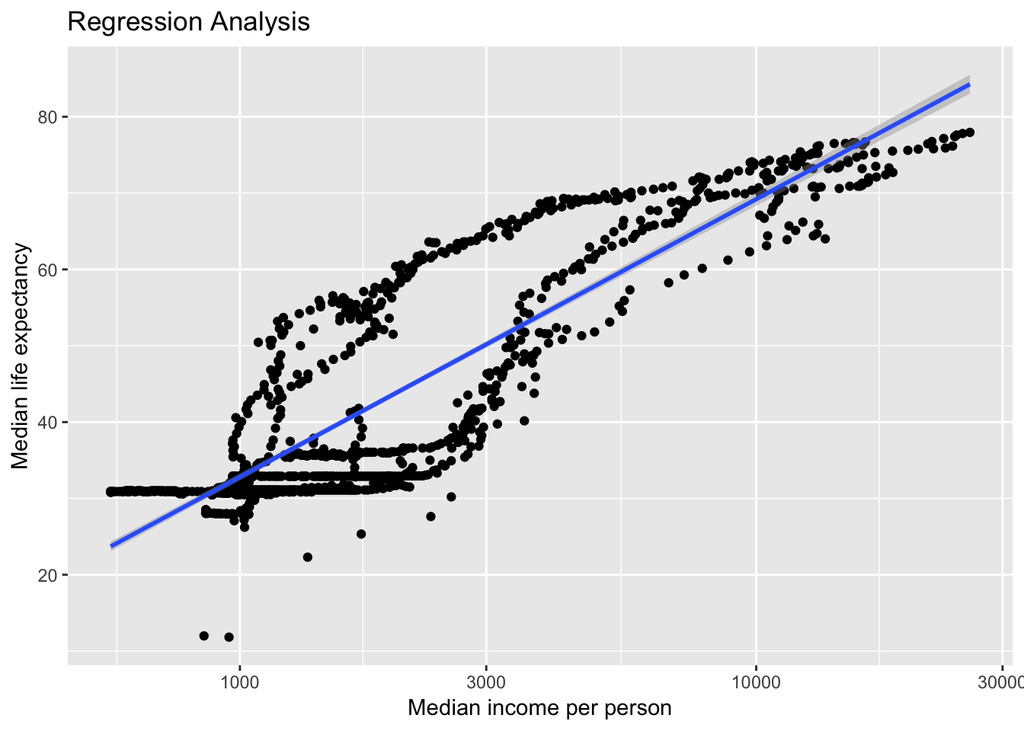

#### Model Diagnostics

Next, we will run some diagnostic test on our linear regression model, utilizing some well-known plots:

- Fitted versus Residuals Plot
- Q-Q Plot
- Scale-Location
- Residuals vs Leverage

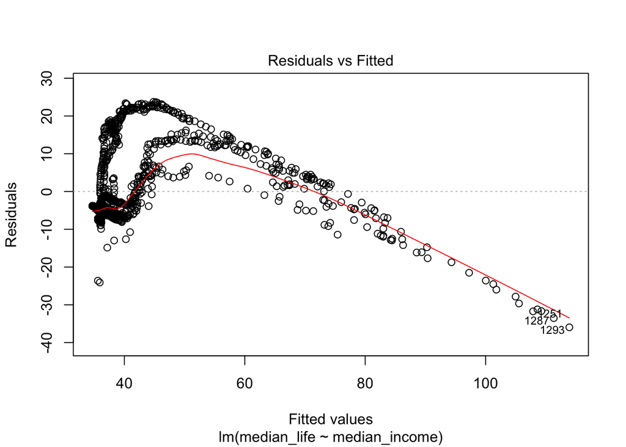

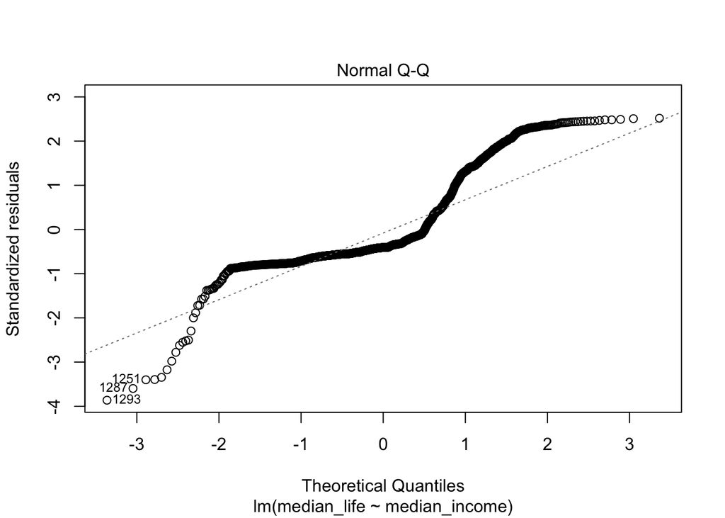

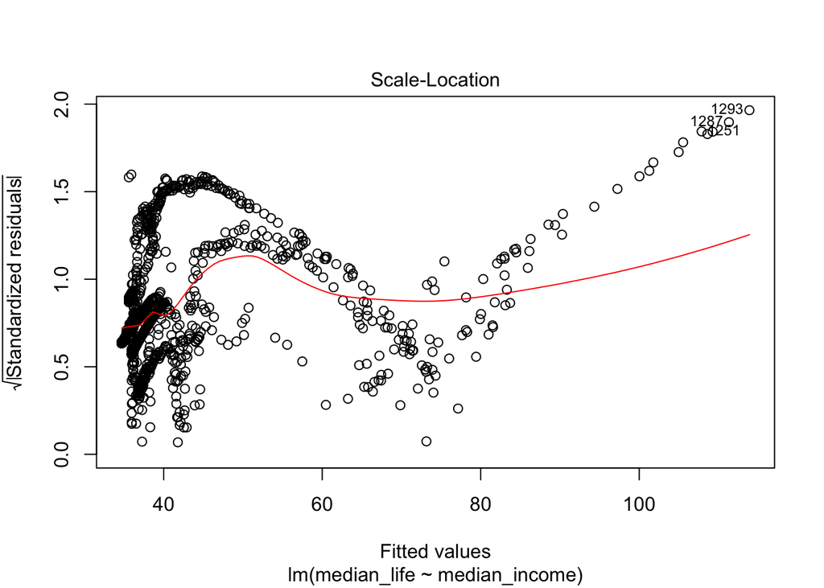

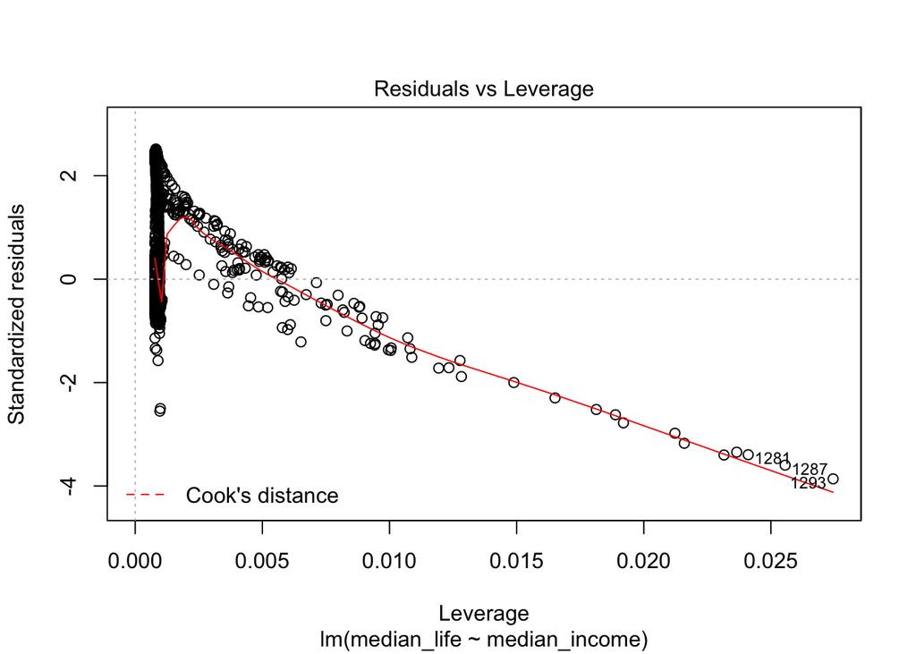

What we are looking for in the fitted versus residuals plot is the assumptions of linearity and constant variance. For linearity, what we should see in the figure above is for the mean of the residuals to be zero. What we find is that this plot shows that the assumption of linearity has been violated. In addition, constant variance assumes the spread at near the fitted points should be roughly the same; the plot indicates that this assumption is also violated.

The Q-Q plot can show us if the data comes from a normal distribution, which is one of the assumptions. If the points in the figure were close to the line, that would indicated that the data are normally distributed. But, our regression model violates this assumption.

The scale-location plot should show an equal spread along the range of predictors. Since the spread is not equal, homoscedasticity is violated.

The final plot is the residuals vs leverage. This plot can display influential data points that impact the regression model. Any points that are outside of Cook’s distance are considered influential. Since we utilized a grouped data set that contained the medians for each region for each year, it makes sense that there would not be any outliers.

## Summary

To summarize the findings, it appears that the pattern that we found, i.e. that median income per person was related to median life expectancy was not a linear relationship. After running the diagnostic tests, the assumptions were violated; however, it could be beneficial to explore this relationship further. Perhaps a different type of regression model can fit this data appropriately. Throughout this exploratory data analysis, there were countless examples that would be worth modeling.

Thank you!